# Análise - Inteligência Computacional - COC 361

Lucas Rolim

9 de outubro de 2016

## Descrição do problema

**Problema: É possível prever a nota IMDB de um filme antes mesmo dele ser lançado?**

Essa será a principal pergunta que irá guiar o desenvolvimento de uma análise de mais de 5000 filmes do site IMDB. Utilizando técncias de aprendizado de máquina e estatística nós iremos não só tentar criar um modelo que seja capaz de responder à pergunta anterior de maneira satistatória como também iremos criar visualizações que nos permitam entender as relações entre essas variáveis.

Esse problema é importante não só para ajudar espectadores em geral a reduzir sua taxa de decepção ao ir ao cinema, mas também de suma importância para a indústria cinematrográfica em si. Filmes, antes de tudo, são investimentos. Conseguir prever se um filme será um fiasco ou um sucesso de bilheteria pode poupar milhões as produtoras de filmes e investidores.

*Para os que desconhecem, o IMDB.com é a principal referência mundial na avaliação da qualidade de filmes. O site conta com dezenas de milhares de filmes com avaliações e críticas produzidas por centenas de milhares de usuários e críticos profissionais*

## Descrição dos Dados

Os dados são originados de um processo de mineração dentro do site IMDB.com. Esse conjunto de dados possui informação de 5043 filmes, lançados ao longo dos últimos 100 anos em 66 países. Ainda, conta com 2399 nomes de diretores e centenas de nomes de atores atrizes.

**As 28 variáveis disponíveis são:**

“color” ; “director_name” ; “num_critic_for_reviews”  
“duration” “director_facebook_likes” “actor_3_facebook_likes”  
“actor_2_name” ; “actor_1_facebook_likes” ; “gross”  
“genres” ; “actor_1_name” ; “movie_title”  
“num_voted_users” ; “cast_total_facebook_likes” ; “actor_3_name”  
“facenumber_in_poster” ; “plot_keywords” ; “movie_imdb_link”  
“num_user_for_reviews” ; “language” “country”  
“content_rating” ; “budget” ; “title_year”  
“actor_2_facebook_likes” ; “imdb_score” ; “aspect_ratio”  
“movie_facebook_likes

## Pré Processamento

### Leitura dos Dados

```r
imdb_data = read.csv("movie_metadata.csv",stringsAsFactors = FALSE)
str(imdb_data)
```

```
## 'data.frame':    5043 obs. of  28 variables:
##  $ color                    : chr  "Color" "Color" "Color" "Color" ...
##  $ director_name            : chr  "James Cameron" "Gore Verbinski" "Sam Mendes" "Christopher Nolan" ...
##  $ num_critic_for_reviews   : int  723 302 602 813 NA 462 392 324 635 375 ...
##  $ duration                 : int  178 169 148 164 NA 132 156 100 141 153 ...
##  $ director_facebook_likes  : int  0 563 0 22000 131 475 0 15 0 282 ...
##  $ actor_3_facebook_likes   : int  855 1000 161 23000 NA 530 4000 284 19000 10000 ...
##  $ actor_2_name             : chr  "Joel David Moore" "Orlando Bloom" "Rory Kinnear" "Christian Bale" ...
##  $ actor_1_facebook_likes   : int  1000 40000 11000 27000 131 640 24000 799 26000 25000 ...
##  $ gross                    : int  760505847 309404152 200074175 448130642 NA 73058679 336530303 200807262 458991599 301956980 ...
##  $ genres                   : chr  "Action|Adventure|Fantasy|Sci-Fi" "Action|Adventure|Fantasy" "Action|Adventure|Thriller" "Action|Thriller" ...
##  $ actor_1_name             : chr  "CCH Pounder" "Johnny Depp" "Christoph Waltz" "Tom Hardy" ...
##  $ movie_title              : chr  "AvatarÂ " "Pirates of the Caribbean: At World's EndÂ " "SpectreÂ " "The Dark Knight RisesÂ " ...
##  $ num_voted_users          : int  886204 471220 275868 1144337 8 212204 383056 294810 462669 321795 ...
##  $ cast_total_facebook_likes: int  4834 48350 11700 106759 143 1873 46055 2036 92000 58753 ...
##  $ actor_3_name             : chr  "Wes Studi" "Jack Davenport" "Stephanie Sigman" "Joseph Gordon-Levitt" ...
##  $ facenumber_in_poster     : int  0 0 1 0 0 1 0 1 4 3 ...
##  $ plot_keywords            : chr  "avatar|future|marine|native|paraplegic" "goddess|marriage ceremony|marriage proposal|pirate|singapore" "bomb|espionage|sequel|spy|terrorist" "deception|imprisonment|lawlessness|police officer|terrorist plot" ...
##  $ movie_imdb_link          : chr  "http://www.imdb.com/title/tt0499549/?ref_=fn_tt_tt_1" "http://www.imdb.com/title/tt0449088/?ref_=fn_tt_tt_1" "http://www.imdb.com/title/tt2379713/?ref_=fn_tt_tt_1" "http://www.imdb.com/title/tt1345836/?ref_=fn_tt_tt_1" ...
##  $ num_user_for_reviews     : int  3054 1238 994 2701 NA 738 1902 387 1117 973 ...
##  $ language                 : chr  "English" "English" "English" "English" ...
##  $ country                  : chr  "USA" "USA" "UK" "USA" ...
##  $ content_rating           : chr  "PG-13" "PG-13" "PG-13" "PG-13" ...
##  $ budget                   : num  2.37e+08 3.00e+08 2.45e+08 2.50e+08 NA ...
##  $ title_year               : int  2009 2007 2015 2012 NA 2012 2007 2010 2015 2009 ...
##  $ actor_2_facebook_likes   : int  936 5000 393 23000 12 632 11000 553 21000 11000 ...
##  $ imdb_score               : num  7.9 7.1 6.8 8.5 7.1 6.6 6.2 7.8 7.5 7.5 ...
##  $ aspect_ratio             : num  1.78 2.35 2.35 2.35 NA 2.35 2.35 1.85 2.35 2.35 ...
##  $ movie_facebook_likes     : int  33000 0 85000 164000 0 24000 0 29000 118000 10000 ...
```

### Normalização dos Dados

Algumas das variáveis de texto do conjunto de dados serão convertidas em variáveis numéricas através de um critério de normalização definido pelas seguintes regras:

- Se o filme foi produzido no EUA a variável *country* será 1, caso contrário será 0;
- Se o filme foi produzido em inglês a variável *language* será 1, caso contrário será 0.
- Todos os filmes terão a variável *director_name* substituida pela média dos filmes já feitos pelo diretor no IMDB,

Essas regras de normalização foram definidas pensando no fato da indústria cinematográfica americana ser a mais bem desenvolvida e com maiores orçamentos do mundo, além de produzir os maiores sucessos das últimas décadas. Logo, espera-se que filmes americanos tenham uma probabilidade maior de pontuar melhor na escala IMDB.

Por fim, passaremos a considerar apenas os valores numéricos do modelo e também desconsideraremos as entradas com valores ausentes.

*A normalização da variável director_name será feita apenas no após o particionamento do conjunto de dados (próximo bloco de código). Esse cuidaod é necessário para que não sejam levados em conta no cálculo da média do IMDB do diretor os filmes que estão no conjunto de testes*

```r
library(dplyr)
imdb_data = na.exclude(imdb_data)
imdb_data$language[imdb_data$language !="English"] = 0
imdb_data$language[imdb_data$language =="English"] = 1
imdb_data$language <- as.numeric(imdb_data$language)
imdb_data$country[imdb_data$country != "USA"] = 0
imdb_data$country[imdb_data$country == "USA"] = 1
imdb_data$country <- as.numeric(imdb_data$country)
```

### Particionamento dos conjunto de dados

Utilizaremos dois conjuntos de dados ao longo das análises, um para treino e um para testes. Essa estratégia visa evitar *(ou ao menos identificar)* o problema de overfitting do modelo no conjunto de treino.

A proporção da separação foi de 70% dos dados para treino e 30% para testes. Essas proporção foi retirada da literatura.

```r
library(caTools)
set.seed(161095)
split = sample.split(imdb_data$imdb_score,SplitRatio = 0.7)
trainData = subset(imdb_data,split == TRUE)
testData = subset(imdb_data,split == FALSE)

# Trecho de normalização do director_name

directorMean <-function(data){
  data = directorHistory [which(directorHistory ==data),2]
  data
}


directorHistory = summarise(group_by(trainData,director_name),mean=mean(imdb_score))
directorIMDB = sapply(trainData$director_name,directorMean)
trainData$director_name <- as.numeric(directorIMDB)
directorIMDB = sapply(testData$director_name,directorMean)
testData$director_name <- as.numeric(directorIMDB)

# fim da normalização do director_name

trainData<- trainData[sapply(trainData,is.numeric)]
testData <- testData[sapply(testData ,is.numeric)]

trainData <- na.exclude(trainData)
testData <- na.exclude(testData)
```

### Definição das Variáveis

Nesse trecho iremos definir de maneira genérica as variáveis que serão utilizadas daqui em diante. Esse processo poupa o trabalho de reescrever código depois e também facilita a manutenção do mesmo.

```r
goal_variable = "imdb_score"
dependent_variable = paste(goal_variable," ~ ")
independent_variables = paste(colnames(trainData)[colnames(trainData) != goal_variable],collapse = "+")
model_variables = paste(dependent_variable,independent_variables)
```

## Visualização geral do Conjunto de Dados

### Histograma

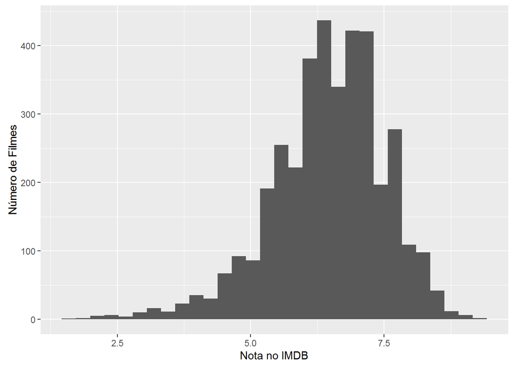

```r
library(ggplot2)
ggplot(imdb_data,aes(x=imdb_score)) + geom_histogram() + xlab("Nota no IMDB") + ylab("Número de Filmes")
```